# Ćwiczenia 6

Patrycja Sarga

18 kwietnia 2023

### Zadanie1: Jeżeli przy wykonywaniu jednego testu prawdopodobieństwo popełnienia błędu wynosi $\alpha=0.05$ (czyli prawdopodobieństwo nie popełnienia błędu wynosi $0.95$) to ile wynosi prawdopodobieństwo, że popełnimy chociaż jeden błąd testując 10 niezależnych hipotez?

A - zdarzenie, polegające na tym, że w 10 niezależnych testach nie zostanie popełniony żaden błąd

B - zdarzenie, polegające na tym, że popełnimy chociaż jeden błąd testując 10 niezależnych hipotez

$P(A) = 0.95^{10} = 0.5987$  
$P(B) = 1 - P(A) = 1 - 0.5987 = 0.4013$

### Zadanie2: Rozważ dane $warpbreaks$. Czego dotyczą te dane? Narysuj odpowiednie wykresy interakcji pomiędzy wool and tension. Wykonaj test anova. Czy zachodzi tutaj interakcja? Skomentuj otrzymane wyniki.

```
##   breaks wool tension
## 1     26    A       L
## 2     30    A       L
## 3     54    A       L
## 4     25    A       L
## 5     70    A       L
## 6     52    A       L
```

```r
summary(warpbreaks)
```

```
##      breaks      wool   tension
##  Min.   :10.00   A:27   L:18
##  1st Qu.:18.25   B:27   M:18
##  Median :26.00          H:18
##  Mean   :28.15
##  3rd Qu.:34.00
##  Max.   :70.00
```

Zestaw danych podaje liczbę zerwań osnowy na krosno, gdzie krosno odpowiada ustalonej długości przędzy.

```r
mean(warpbreaks[warpbreaks$wool == "A" & warpbreaks$tension == "L",]$breaks)
```

```
## [1] 44.55556
```

```r
mean(warpbreaks[warpbreaks$wool == "A" & warpbreaks$tension == "H",]$breaks)
```

```
## [1] 24.55556
```

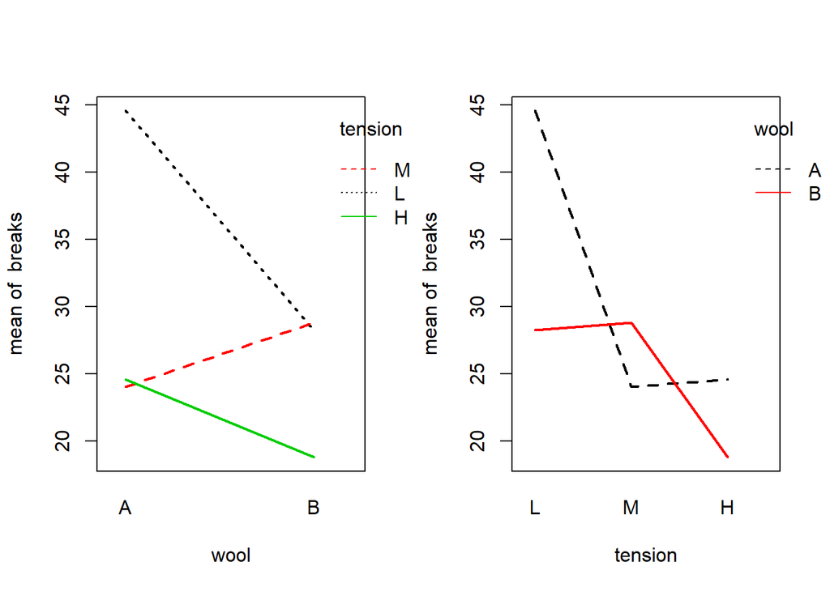

```r
options(repr.plot.width=10, repr.plot.height=5)

par(mfrow = c(1, 2))
with(warpbreaks, interaction.plot(wool, tension, breaks, lwd = 2, col = 1:4))
with(warpbreaks, interaction.plot(tension, wool, breaks, lwd = 2, col = 1:3))
```

```r
warp_int = aov(breaks ~ wool:tension, data = warpbreaks) #model interakcji

warp_table = expand.grid(wool = unique(warpbreaks$wool), tension = unique(warpbreaks$tension))
print(warp_table)
```

```
##   wool tension
## 1    A       L
## 2    B       L
## 3    A       M
## 4    B       M
## 5    A       H
## 6    B       H
```

```r
print(matrix(paste0(warp_table$wool, "-", warp_table$tension) , 3, 2, byrow = TRUE))
```

```
##      [,1]  [,2]
## [1,] "A-L" "B-L"
## [2,] "A-M" "B-M"
## [3,] "A-H" "B-H"
```

```r
#estymuje srednie

get_est_means = function(model, table) {
mat = matrix(predict(model, table), nrow = 2, ncol = 3, byrow = TRUE)
colnames(mat) = c("L", "M", "H")
rownames(mat) = c("A", "B")
mat
}
```

```r
knitr::kable(get_est_means(model = warp_int, table = warp_table)) #interaction model
```

|  | L | M | H |
| --- | --- | --- | --- |
| A | 44.55556 | 28.22222 | 24.00000 |
| B | 28.77778 | 24.55556 | 18.77778 |

```r
interaction_means = get_est_means(model = warp_int, table = warp_table)
interaction_means["A",] - interaction_means["B",] #efekt leczenia w modelu z interakcją (rozne wartosci)
```

```
##         L         M         H
## 15.777778  3.666667  5.222222
```

```r
summary(aov(breaks ~ wool:tension, data = warpbreaks)) #interakcja jest znacząca (***)
```

```
##              Df Sum Sq Mean Sq F value   Pr(>F)
## wool:tension  5   3488   697.5   5.828 0.000277 ***
## Residuals    48   5745   119.7
## ---
## Signif. codes:  0 '***' 0.001 '**' 0.01 '*' 0.05 '.' 0.1 ' ' 1
```

```r
TukeyHSD(aov(breaks ~ wool + tension + wool:tension, data = warpbreaks))
```

```
##   Tukey multiple comparisons of means
##     95% family-wise confidence level
##
## Fit: aov(formula = breaks ~ wool + tension + wool:tension, data = warpbreaks)
##
## $wool
##          diff       lwr       upr    p adj
## B-A -5.777778 -11.76458 0.2090243 0.058213
##
## $tension
##           diff       lwr       upr     p adj
## M-L -10.000000 -18.81965 -1.180353 0.0228554
## H-L -14.722222 -23.54187 -5.902575 0.0005595
## H-M  -4.722222 -13.54187  4.097425 0.4049442
##
## $`wool:tension`
##                diff       lwr        upr     p adj
## B:L-A:L -16.3333333 -31.63966  -1.027012 0.0302143
## A:M-A:L -20.5555556 -35.86188  -5.249234 0.0029580
## B:M-A:L -15.7777778 -31.08410  -0.471456 0.0398172
## A:H-A:L -20.0000000 -35.30632  -4.693678 0.0040955
## B:H-A:L -25.7777778 -41.08410 -10.471456 0.0001136
## A:M-B:L  -4.2222222 -19.52854  11.084100 0.9626541
## B:M-B:L   0.5555556 -14.75077  15.861877 0.9999978
## A:H-B:L  -3.6666667 -18.97299  11.639655 0.9797123
## B:H-B:L  -9.4444444 -24.75077   5.861877 0.4560950
## B:M-A:M   4.7777778 -10.52854  20.084100 0.9377205
## A:H-A:M   0.5555556 -14.75077  15.861877 0.9999978
## B:H-A:M  -5.2222222 -20.52854  10.084100 0.9114780
## A:H-B:M  -4.2222222 -19.52854  11.084100 0.9626541
## B:H-B:M -10.0000000 -25.30632   5.306322 0.3918767
## B:H-A:H  -5.7777778 -21.08410   9.528544 0.8705572
```

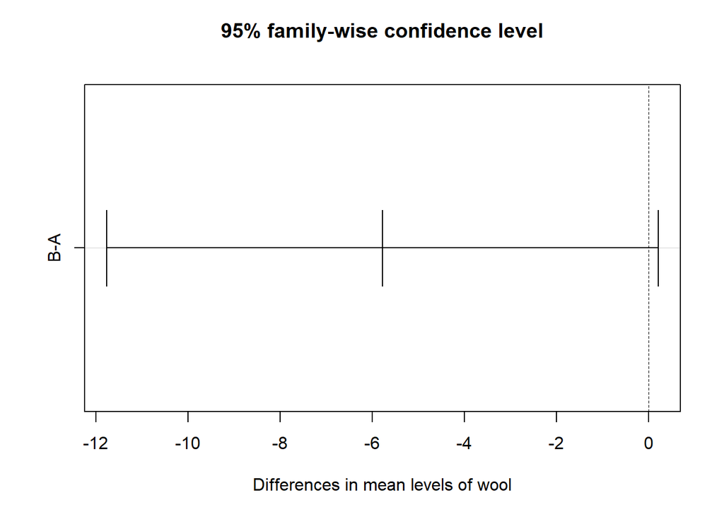

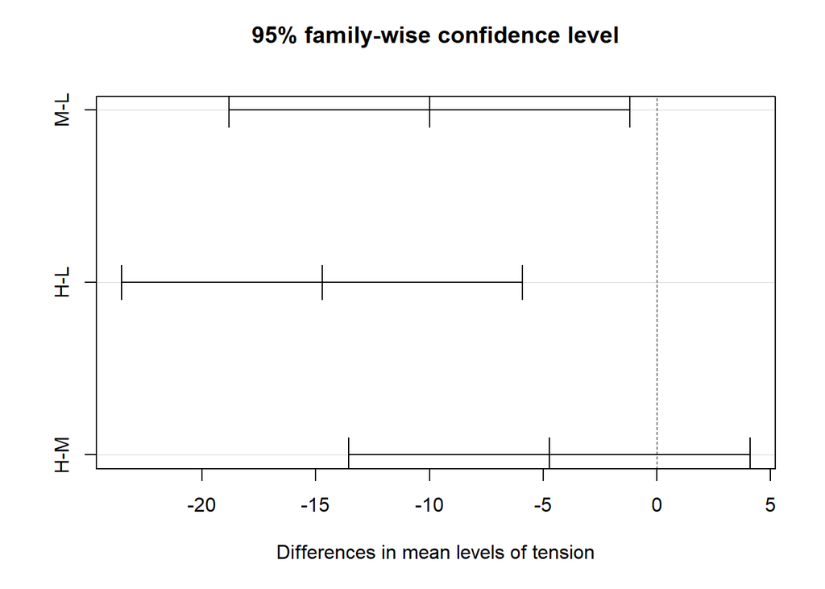

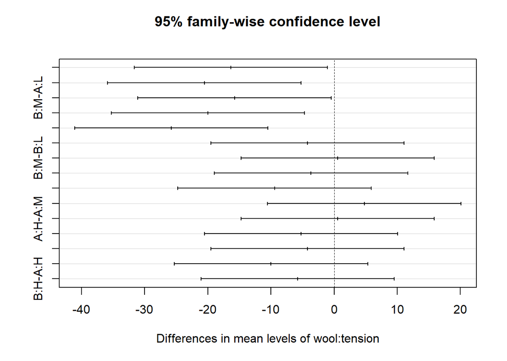

```r
plot(TukeyHSD(aov(breaks ~ wool + tension + wool:tension, data = warpbreaks)))
```

W oparciu o wykonany test *Tukey’a* oraz nakreślone wykresy wnioskuje się występowanie następujących interakcji: B:L-A:L, A:M-A:L, B:M-A:L, A:H-A:L, B:H-A:L - porównanie złożenia tych cech dało wartość p-adjusment mniejszą od 0.05, co sugeruje odrzucenie hipotezy zerową, jaką był brak interakcji pomiędzy cechami, zatem interakcja w tych przypadkach występuje. Na wykresie dla tych cech obserwuje się przesunięcie danych od osi y=0.

### Zadanie3: Zaproponuj odpowiednią transformację danych tak aby rozkład danych po tej operacji był normalny.

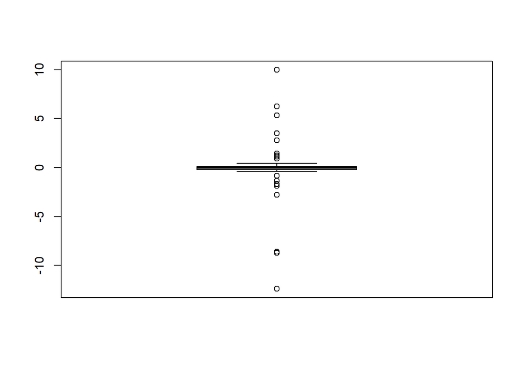

```r
options(repr.plot.width=3, repr.plot.height=3)
y = c(-0.11,6.26,0.07,-0.29,-0.16,1.1,0,1.41,5.33,-1.7,0.4,-1.66,-0.83,-0.02,0,-0.06,-0.01,-0.08,-0.18,-8.74,1.24,-0.41,-1.87,0.93,0.01,9.97,0.11,0.01,2.78,-0.32,0.01,-0.22,0.44,0.01,-8.62,0.02,0.08,-12.39,0,0.17,0.1,-2.78,3.51,0.06,-0.01,0,0.08,-1.37,0.02,0)
boxplot(y)
```

```r
shapiro.test(y)
```

```
##
##  Shapiro-Wilk normality test
##
## data:  y
## W = 0.71257, p-value = 1.401e-08
```

Jednym z warunków, aby móc do analizy używać testów parametrycznych, takich jak t.test, ANOVA, konieczne jest, aby dane na których ma oprzeć się analiza miały rozkład normalny.

W tym przypadku obserwując dane na wykresie pudełkowym widzimy, że nie mają one charakteru rozkładu normalnego - większość danych jest skumulowana w bardzo wąskim zakresie, natomiast całość danych mięści się w szerokim zakresie. Brak normaloności rozkładu potwierdza również wykonany test Shapiro-Wilka.

W celu uzyskania możliwości wykonania testu parametrycznego, a więc uzyskania normalności rozkładu danych wykonuje się transformację danych bazując na dwóch operacjach: potęgowania i logarytmowania.

Dane dostępne w tym zadaniu transformujemy poprzez potęgowanie, zachowując ponadto znak każdej wartości (przy pomocy funkcji *sign()*)

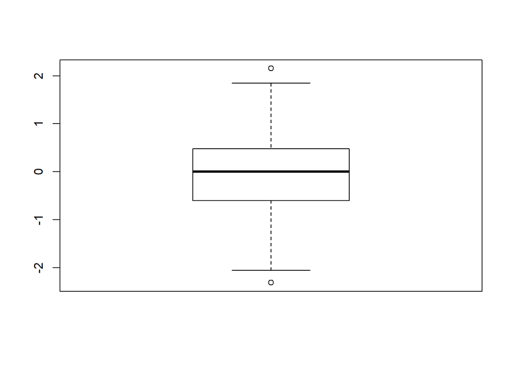

```r
y2 = sign(y) * abs(y)^(1/3)
boxplot(y2)
```

```r
shapiro.test(y2)
```

```
##
##  Shapiro-Wilk normality test
##
## data:  y2
## W = 0.98672, p-value = 0.8422
```

Dokonano transformacji podnosząc dane do potęgi $1/3$. W efekcie otrzymaliśmy zestaw danych, który w oparciu o test Shapiro-Wilka ma charakter rozkładu normalnego ($p-value > 0.05$)